# Ilustración Regularización

Prof. Juan David Ospina Arango Universidad Nacional - Sede Medellín Analítica Predictiva Semestre 2020-01

## Publicidad y Ventas

Carga del conjunto de datos:

```r
Advertising <- read.csv("Advertising.csv")
```

Particionamiento del conjunto de datos en entrenamiento y validación:

```r
set.seed(08042020)
p<-0.6
N<-dim(Advertising)[1]
val<-sample(N,round(N*(1-p)),replace = FALSE)

data_tr<-Advertising[-val,-1]
data_vl<-Advertising[val,-1]
```

Modelo de regresión lineal con interacciones:

```r
modelo01<-lm(sales~(TV+radio+newspaper)^2,data=data_tr)
summary(modelo01)
```

```
##
## Call:
## lm(formula = sales ~ (TV + radio + newspaper)^2, data = data_tr)
##
## Residuals:
##     Min      1Q  Median      3Q     Max
## -5.2664 -0.4205  0.2545  0.6516  1.5173
##
## Coefficients:
##                   Estimate Std. Error t value Pr(>|t|)
## (Intercept)      6.117e+00  4.187e-01  14.609  < 2e-16 ***
## TV               2.223e-02  2.133e-03  10.424  < 2e-16 ***
## radio            1.255e-02  1.591e-02   0.789  0.43192
## newspaper        2.958e-02  1.487e-02   1.990  0.04906 *
## TV:radio         1.220e-03  7.832e-05  15.575  < 2e-16 ***
## TV:newspaper    -1.571e-04  5.220e-05  -3.009  0.00323 **
## radio:newspaper -1.537e-04  3.501e-04  -0.439  0.66150
## ---
## Signif. codes:  0 '***' 0.001 '**' 0.01 '*' 0.05 '.' 0.1 ' ' 1
##
## Residual standard error: 1.033 on 113 degrees of freedom
## Multiple R-squared:  0.9659, Adjusted R-squared:  0.9641
## F-statistic: 534.3 on 6 and 113 DF,  p-value: < 2.2e-16
```

Notemos que la combinación `radio:newspaper` puede ser eliminada del modelo, pero no la variable `radio`, pues `TV:radio` es significativa.

### Estandarización de variables:

Para escalar los datos se usará solo el conjunto de entrenamiento:

```r
data_tr_s<-scale(data_tr)
```

Los parámetros de preprocesamiento se guardan en los objetos `data_tr_mean` y `data_tr_stdv`:

```r
data_tr_mean<-attr(data_tr_s,"scaled:center")
data_tr_stdv<-attr(data_tr_s,"scaled:scale")
data_tr_s<-as.data.frame(data_tr_s) # la matriz escalada se convierte nuevamente en un dataframe
```

A continuación se entrena el modelo con los datos escalados. Para ello se define aparte la fórmula `f1` que relaciona las variables:

```r
f1<-formula(sales~-1+(TV+radio+newspaper)^2,data=data_tr_s) # fórmula
data_tr_matrix<-model.matrix(f1,data=as.data.frame(data_tr_s)) # creación de la matrix X del entrentamiento
data_tr_matrix<-as.data.frame(data_tr_matrix) # conversión de la matriz en dataframe
```

Ahora se agrega a la matriz anterior la variable respuesta y se estima el modelo con los datos centrados:

```r
data_tr_matrix$sales<-data_tr_s$sales # se agrega la respuesta al dataframe de entrenamiento
modelo02<-lm(sales~.,data=data_tr_matrix) # se calibra el modelo con todas las variables
summary(modelo02)
```

```
##
## Call:
## lm(formula = sales ~ ., data = data_tr_matrix)
##
## Residuals:
##      Min       1Q   Median       3Q      Max
## -0.96531 -0.07708  0.04665  0.11943  0.27811
##
## Coefficients:
##                    Estimate Std. Error t value Pr(>|t|)
## (Intercept)       -0.001313   0.019750  -0.066  0.94710
## TV                 0.730870   0.017958  40.699  < 2e-16 ***
## radio              0.523245   0.019274  27.147  < 2e-16 ***
## newspaper          0.011726   0.022437   0.523  0.60226
## `TV:radio`         0.300825   0.019315  15.575  < 2e-16 ***
## `TV:newspaper`    -0.053595   0.017809  -3.009  0.00323 **
## `radio:newspaper` -0.009070   0.020661  -0.439  0.66150
## ---
## Signif. codes:  0 '***' 0.001 '**' 0.01 '*' 0.05 '.' 0.1 ' ' 1
##
## Residual standard error: 0.1894 on 113 degrees of freedom
## Multiple R-squared:  0.9659, Adjusted R-squared:  0.9641
## F-statistic: 534.3 on 6 and 113 DF,  p-value: < 2.2e-16
```

**Tarea**: eliminar el intercepto y la variable `radio:newspaper` usando la función `update()`.

#### Ajuste:

Visualización de predichos vs reales:

```r
y1_tr<-predict(modelo01)
y2_tr<-predict(modelo02)*data_tr_stdv[4]+data_tr_mean[4]
```

Predichos vs observados del modelo sin estandarización:

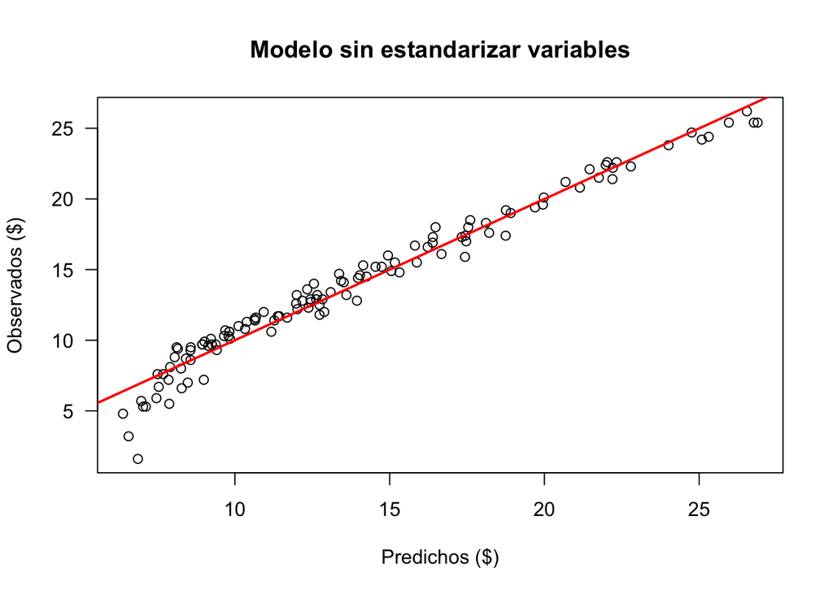

```r
plot(y1_tr,data_tr$sales,las=1,xlab="Predichos ($)",
     ylab="Observados ($)",
     main="Modelo sin estandarizar variables")
abline(a=0,b=1,lwd=2,col="red")
```

Predichos vs observados del modelo estandarizado:

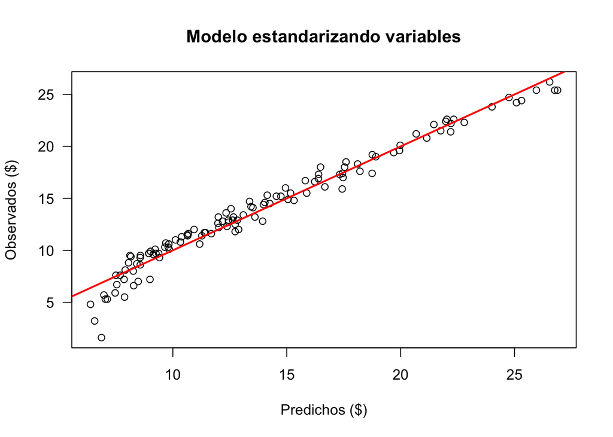

```r
plot(y2_tr,data_tr$sales,las=1,xlab="Predichos ($)",
     ylab="Observados ($)",
     main="Modelo estandarizando variables")
abline(a=0,b=1,lwd=2,col="red")
```

## Capacidad predictiva

Predicciones con el modelo sin estandarizar variables:

```r
y1_vl<-predict(modelo01,newdata = data_vl)
```

Ahora se preprocesan los datos de validación para aplicar el modelo con variables estandarizadas:

```r
data_vl_s<-scale(data_vl,center = data_tr_mean, scale = data_tr_stdv) # se escalan los datos con los parámetros de media y desviación estándar del conjunto de datos de entrenamiento.
data_vl_s<-as.data.frame(data_vl_s)

data_vl_matrix<-model.matrix(f1,data=as.data.frame(data_vl_s))
data_vl_matrix<-as.data.frame(data_vl_matrix)
```

Se predicen los datos con el modelo entrenado con variables estandarizadas:

```r
y2_vl<-predict(modelo02,newdata = data_vl_matrix)*data_tr_stdv[4]+data_tr_mean[4]
```

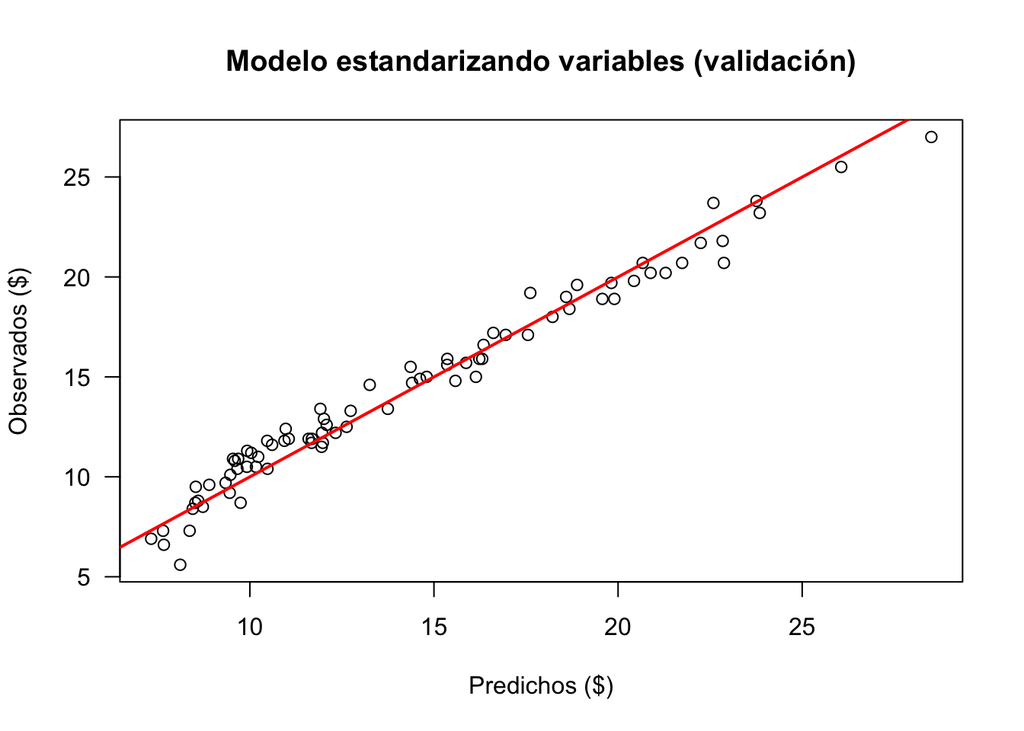

```r
plot(y2_vl,data_vl$sales,las=1,xlab="Predichos ($)",
     ylab="Observados ($)",
     main="Modelo estandarizando variables (validación)")
abline(a=0,b=1,lwd=2,col="red")
```

## Calibración de un modelo con regularización:

El paquete `glmnet` permite calibrar modelos con regularización:

```r
library(glmnet)
```

Calibración del modelo lasso con distintos valores para $\lambda$:

```r
X<-model.matrix(f1,data=as.data.frame(data_tr_s))
y<-data_tr_s$sales
modelo03<-glmnet(X,y,alpha=1)
```

Cantidad de variables versus norma L1:

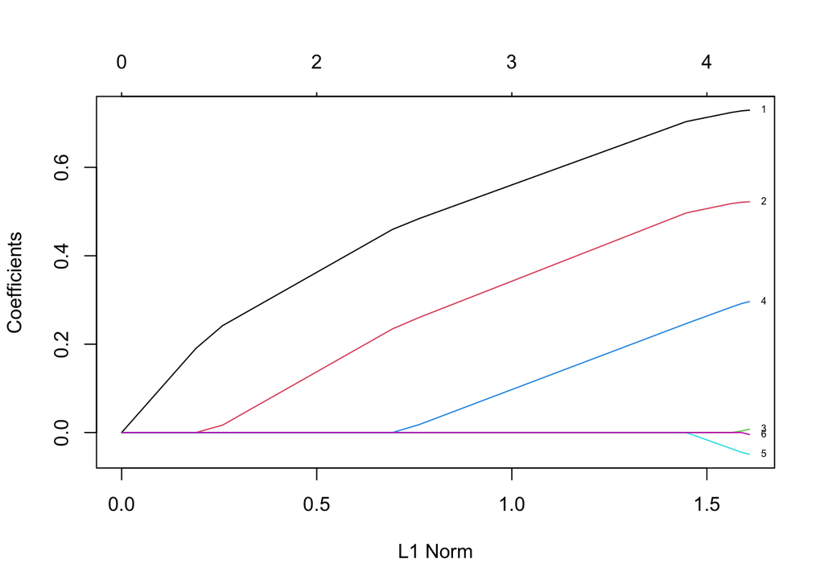

```r
plot(modelo03,xvar = c("norm"),label=TRUE)
```

Cantidad de variables versus $\lambda$:

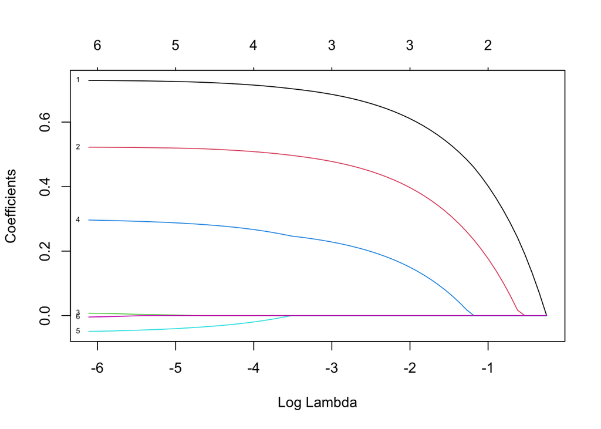

```r
plot(modelo03,xvar = c("lambda"),label=TRUE)
```

Para determinar el valor de $\lambda$ óptimo se utiliza la función `cv.glmnet`:

```r
grid<-10^seq(10,-2,length=100)
modelo04<-cv.glmnet(X,y,alpha=1,lambda=grid) # alpha=1 es lasso
```

Visualización del error en función de $\lambda$:

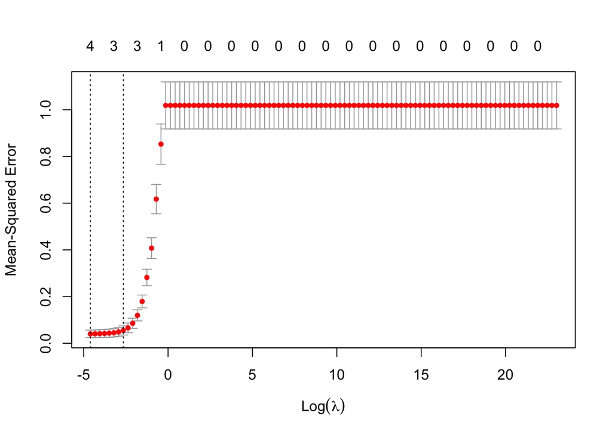

```r
plot(modelo04)
```

Calibración del modelo con el $\lambda$ óptimo (de validación cruzada):

```r
lambda_opt<-modelo04$lambda.min
modelo04<-glmnet(X,y,alpha=1,lambda = lambda_opt)
```

Cálculo de las predicciones del modelo lasso (entrenamiento):

```r
y4_tr<-predict(modelo04,newx = X)*data_tr_stdv[4]+data_tr_mean[4]
```

Predichos versus observados del modelo lasso en entrenamiento:

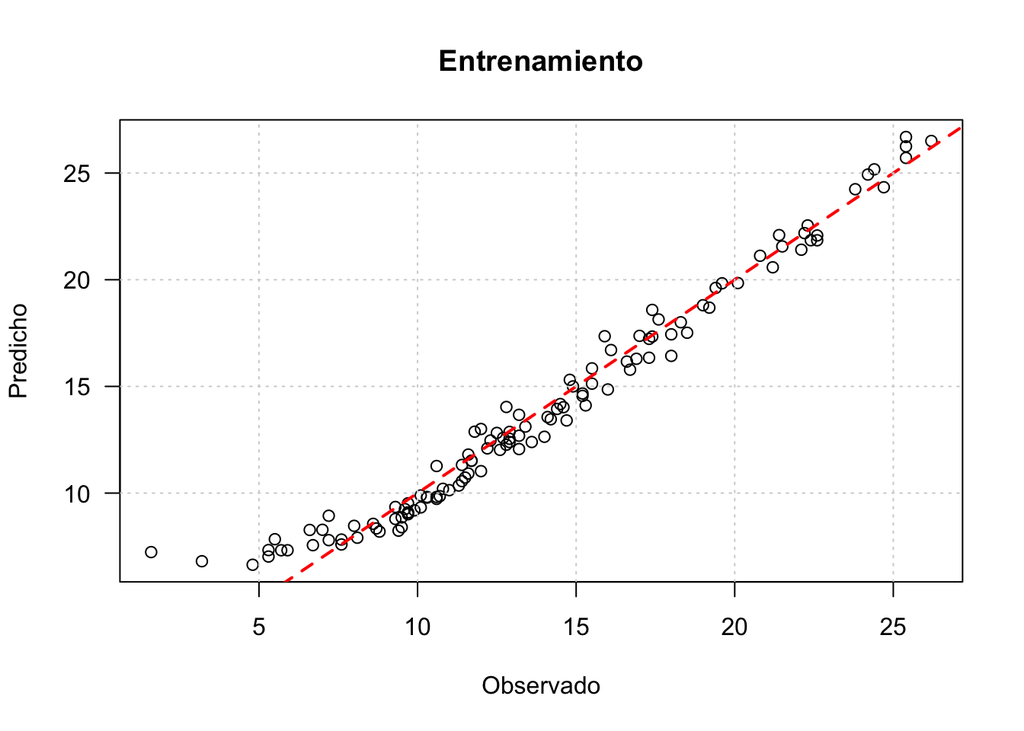

```r
plot(Advertising$sales[-val],y4_tr,las=1,
     xlab="Observado",ylab="Predicho",main="Entrenamiento")
abline(a=0,b=1,lwd=2,col="red",lty=2)
grid()
```

Coeficientes del modelo lasso:

```r
modelo04$a0
```

```
##           s0
## -0.008418503
```

```r
modelo04$beta
```

```
## 6 x 1 sparse Matrix of class "dgCMatrix"
##                          s0
## TV               0.72301673
## radio            0.51685170
## newspaper        .
## TV:radio         0.28170371
## TV:newspaper    -0.03437839
## radio:newspaper  .
```

Cálculo de las predicciones del modelo lasso (validación):

```r
X_vl<-model.matrix(f1,data=as.data.frame(data_vl_s))
y4_vl<-predict(modelo04,newx = X_vl)*data_tr_stdv[4]+data_tr_mean[4]
```

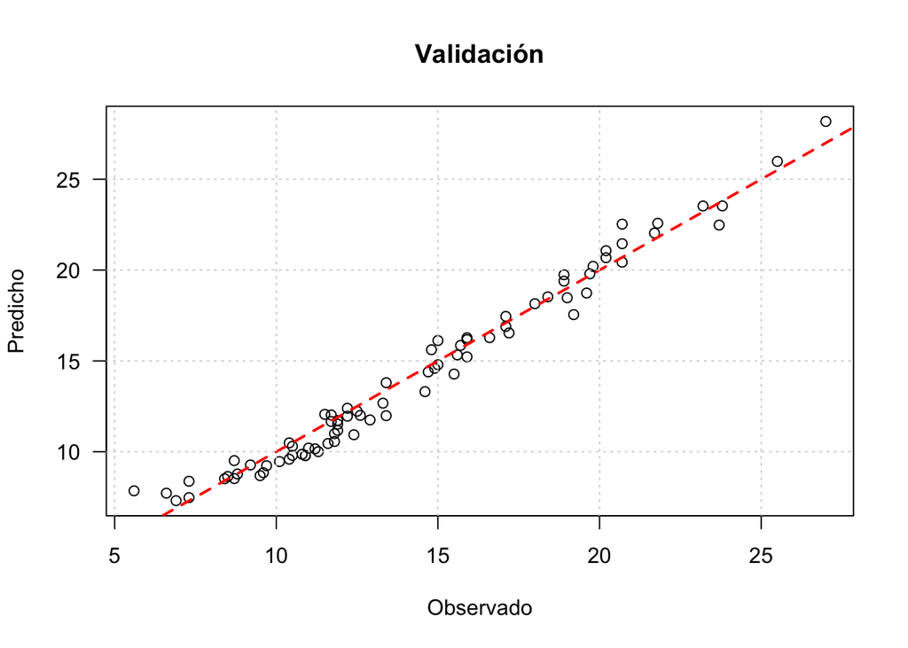

```r
plot(Advertising$sales[val],y4_vl,las=1,
     xlab="Observado",ylab="Predicho",main="Validación")
abline(a=0,b=1,lwd=2,col="red",lty=2)
grid()
```

**Tarea**: 1. Eliminar las variables no significativas de los modelos 2. Calcular el RMSE de entrenamiento y validación para todos los modelos 3. Construir una explicación de porqué el modelo no ajusta para valores de ventas bajos (en entrenamiento).

## Bonus: stepwise selection

```r
modelo01_step<-step(modelo01,direction = "backward")
```

```
## Start:  AIC=14.61
## sales ~ (TV + radio + newspaper)^2
##
##                   Df Sum of Sq    RSS     AIC
## - radio:newspaper  1     0.206 120.81  12.810
## <none>                         120.61  14.605
## - TV:newspaper     1     9.667 130.27  21.857
## - TV:radio         1   258.912 379.52 150.169
##
## Step:  AIC=12.81
## sales ~ TV + radio + newspaper + TV:radio + TV:newspaper
##
##                Df Sum of Sq    RSS     AIC
## <none>                      120.81  12.810
## - TV:newspaper  1     9.527 130.34  19.918
## - TV:radio      1   260.032 380.84 148.588
```